# Data Handling: Import, Cleaning and Visualisation

04/10/2018

## Recap

## The binary system

Microprocessors can only represent two signs (states):

- 'Off' = `0`
- 'On' = `1`

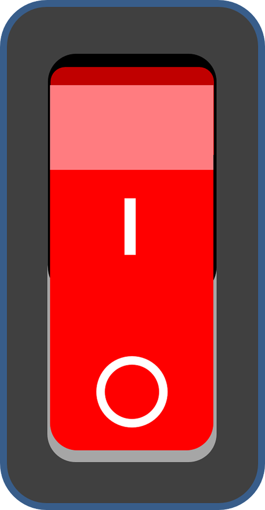

## The binary counting frame

- Only two signs: `0`, `1`.
- Base 2.
- Columns: \(2^0=1\), \(2^1=2\), \(2^3=4\), and so forth.

## The hexadecimal system

- Binary numbers can become quite long rather quickly.
- Computer Science: refer to binary numbers with the *hexadecimal* system.
- 16 symbols:
- `0`-`9` (used like in the decimal system)…
- and `A`-`F` (for the numbers 10 to 15).
- 16 symbols: base 16: each digit represents an increasing power of 16 (\(16^{0}\), \(16^{1}\), etc.).

## Computers and text

How can a computer understand text if it only understands `0`s and `1`s?

- *Standards* define how `0`s and `1`s correspond to specific letters/characters of different human languages.
- These standards are usually called *character encodings*.
- Coded character sets that map unique numbers (in the end in binary coded values) to each character in the set.
- For example, ASCII (American Standard Code for Information Interchange).

## ASCII Table

| Binary | Hexadecimal | Decimal | Character |
| --- | --- | --- | --- |
| 0011 1111 | 3F | 63 | `?` |
| 0100 0001 | 41 | 65 | `A` |
| 0110 0010 | 62 | 98 | `b` |

## Putting the pieces together…

Two core themes of this course:

1. How can *data* be *stored* digitally and be *read* by/imported to a computer?
2. How can we give instructions to a computer by writing *computer code*?

In both of these domains we mainly work with one simple type of document: *text files*.

## Text-files

- A *collection of characters* stored in a designated part of the computer memory/hard drive.
- A easy to read representation of the underlying information (`0`s and `1`s)!
- Common device to store data:
  - Structured data (tables)
  - Semi-structured data (websites)
  - Unstructured data (plain text)
- Typical device to store computer code.

## Digital data processing

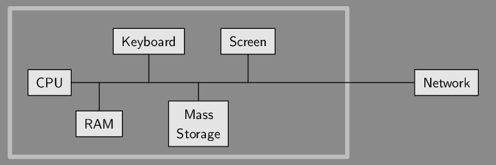

Basic components of a standard computing environment. Figure by Murrell (2009) (Figure 9.1, licensed under [CC BY-NC-SA 3.0 NZ](https://creativecommons.org/licenses/by-nc-sa/3.0/nz/)).

## Putting the pieces together…

Recall the initial example (survey) of this course.

1. Access a website (over the Internet), use keyboard to enter data into a website (a Google sheet in that case).
2. R program accesses the data of the Google sheet (again over the Internet), download the data, and load it into RAM.
3. Data processing: produce output (in the form of statistics/plots), output on screen.

## Computer Code and Data Storage

## Computer code

- Instructions to a computer, in a language it understands… (R)
- Code is written to *text files*
- Text is 'translated' into 0s and 1s which the CPU can process.

## Data storage

- Data usually stored in *text files*
- Code is written to *text files*
- Read data from text files: data import.
- Write data to text files: data export.

## Unstructured data in text files

- Store `Hello World!` in `helloworld.txt`.
- Allocation of a block of computer memory containing `Hello World!`.
- Simply a sequence of `0`s and `1`s…
- `.txt` indicates to the operating system which program to use when opening this file.
- Encoding and format tell the computer how to interpret the `0`s and `1`s.

## Inspect a text file

Interpreting `0`s and `1`s as text…

```bash
cat helloworld.txt; echo
```

```
## Hello World!
```

## Inspect a text file

Directly looking at the `0`s and `1`s…

```bash
xxd -b helloworld.txt
```

```
## 00000000: 01001000 01100101 01101100 01101100 01101111 00100000  Hello
## 00000006: 01010111 01101111 01110010 01101100 01100100 00100001  World!
```

## Inspect a text file

Similarly we can display the content in hexadecimal values:

```bash
xxd  data/helloworld.txt
```

```
## 00000000: 4865 6c6c 6f20 576f 726c 6421            Hello World!
```

## Encoding issues

```bash
cat hastamanana.txt; echo
```

```
## Hasta Ma?ana!
```

- What is the problem?

## Encoding issues

Inspect the encoding

```bash
file -b hastamanana.txt
```

```
## ISO-8859 text
```

## Use the correct encoding

Read the file again, this time with the correct encoding

```
iconv -f iso-8859-1 -t utf-8 hastamanana.txt | cat
```

```
## Hasta Mañana!
```

## UTF encodings

- 'Universal' standards.
- Contain broad variaty of symbols (various languages).
- Less problems with newer data sources…

## Take-away message

- *Recognize an encoding issue when it occurs!*
- Problem occurs right at the beginning of the *data pipeline*!
  - Rest of pipeline affected…
  - … cleaning of data fails …
  - … analysis suffers.

## Structured Data Formats

- Still text files, but with standardized *structure*.
- *Special characters* define the structure.
- More complex *syntax*, more complex structures can be represented…

## Table-like formats

Example `ch_gdp.csv`.

```
year,gdp_chfb
1980,184
1985,244
1990,331
1995,374
2000,422
2005,464
```

*What is the structure?*

## Table-like formats

- What is the reocurring pattern?
- Special character `,`
- New lines
- Table is visible from structure in raw text file…

*How can we instruct a computer to read this text as a table?*

## A simple parser algorithm

1. Start with an empty table consisting of one cell (1 row/column).
2. While the end of the input file is not yet reached, do the following:

## A simple parser algorithm

1. Start with an empty table consisting of one cell (1 row/column).
2. While the end of the input file is not yet reached, do the following:
   - Read characters from the input file, and add them one-by-one to the current cell.

## A simple parser algorithm

1. Start with an empty table consisting of one cell (1 row/column).
2. While the end of the input file is not yet reached, do the following:
   - Read characters from the input file, and add them one-by-one to the current cell.

     -If you encounter the character '`,`', ignore it, create a new field, and jump to the new field.

## A simple parser algorithm

1. Start with an empty table consisting of one cell (1 row/column).
2. While the end of the input file is not yet reached, do the following:
   - Read characters from the input file, and add them one-by-one to the current cell.

     -If you encounter the character '`,`', ignore it, create a new field, and jump to the new field.
   - If you encounter the end of the line, create a new row and jump to the new row.

## CSVs and fixed-width format

- *'Comma-Separated Values'* (therefore `.csv`)
  - commas separate values
  - new lines separate rows/observations
  - (many related formats with other separators)
- Instructions of how to read a `.csv`-file: *CSV parser*.

## CSVs and fixed-width format

- Common format to store and transfer data.
  - Very common in a data analysis context.
- Natural format/structure when data represents a table.

## CSVs and fixed-width format

*How does the computer know that the end of a line is reached?*

## CSVs and fixed-width format

*How does the computer know that the end of a line is reached?*

## End-of-line characters

```bash
xxd ch_gdp.csv
```

```
## 00000000: efbb bf79 6561 722c 6764 705f 6368 6662  ...year,gdp_chfb
## 00000010: 0d31 3938 302c 3138 340d 3139 3835 2c32  .1980,184.1985,2
## 00000020: 3434 0d31 3939 302c 3333 310d 3139 3935  44.1990,331.1995
## 00000030: 2c33 3734 0d32 3030 302c 3432 320d 3230  ,374.2000,422.20
## 00000040: 3035 2c34 3634                           05,464
```

## End-of-line characters

```bash
xxd ch_gdp.csv
```

```
## 00000000: efbb bf79 6561 722c 6764 705f 6368 6662  ...year,gdp_chfb
## 00000010: 0d31 3938 302c 3138 340d 3139 3835 2c32  .1980,184.1985,2
## 00000020: 3434 0d31 3939 302c 3333 310d 3139 3935  44.1990,331.1995
## 00000030: 2c33 3734 0d32 3030 302c 3432 320d 3230  ,374.2000,422.20
## 00000040: 3035 2c34 3634                           05,464
```

- `.` (`0d`): indicates end of line!

## Related formats

- Other delimiters (`;`, tabs, etc.)
- Fixed (column) width

## More complex formats

- N-dimensional data
- Nested data
- *XML*, *JSON*, *YAML*, etc.
  - Often encountered online!
  - (Next lecture!)

## Units of Information/Data Storage

## Bit, Byte, Word

- Smallest unit (a `0` or a `1`): *bit* (from *bi*nary dig*it*; abbrev. 'b').
- *Byte* (1 byte = 8 bits; abbrev. 'B')
  - For example, `10001011` (`139`)
- 4 bytes (or 32 bits) are called a *word*.

## Bit, Byte, Word

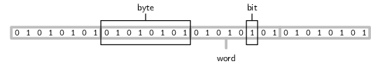

Bit, Byte, Word. Figure by Murrell (2009) (licensed under [CC BY-NC-SA 3.0 NZ](https://creativecommons.org/licenses/by-nc-sa/3.0/nz/))

## Bigger units for storage capacity

- \(1 \text{ kilobyte (KB)} = 1000^{1} \text{ bytes}\)
- \(1 \text{ megabyte (MB)} = 1000^{2} \text{ bytes}\)
- \(1 \text{ gigabyte (GB)} = 1000^{3} \text{ bytes}\)

## Common units for data transfer (over a network)

- \(1 \text{ kilobit per second (kbit/s)} = 1000^{1} \text{ bit/s}\)
- \(1 \text{ megabit per second (mbit/s)} = 1000^{2} \text{ bit/s}\)
- \(1 \text{ gigabit per second (gbit/s)} = 1000^{3} \text{ bit/s}\)

## Data structures and data types in R

## Structures to work with…

- Data structures for storage on hard drive (e.g., csv).
- Representation of data in RAM (e.g. as an R-object)?
- What is the representation of the 'structure' once the data is parsed (read into RAM)?

## Structures to work with (in R)

We distinguish two basic characteristics:

1. Data **types**: integers; real numbers ('numeric values', floating point numbers); text ('string', 'character values').

## Structures to work with (in R)

We distinguish two basic characteristics:

1. Data **types**: integers; real numbers ('numeric values', floating point numbers); text ('string', 'character values').
2. Basic **data structures** in RAM:
   - *Vectors*
   - *Factors*
   - *Arrays/Matrices*
   - *Lists*
   - *Data frames* (very `R`-specific)

## Data types: numeric

```r
a <- 1.5
b <- 3
```

R interprets this data as type `double` (class 'numeric'):

```r
typeof(a)
```

```
## [1] "double"
```

```r
class(a)
```

```
## [1] "numeric"
```

## Data types: numeric

Given that these bytes of data are interpreted as numeric, we can use operators (here: math operators) that can work with such functions:

```r
a + b
```

```
## [1] 4.5
```

## Data types: character

```r
a <- "1.5"
b <- "3"
```

```r
typeof(a)
```

```
## [1] "character"
```

```r
class(a)
```

```
## [1] "character"
```

## Data types: character

Now the same line of code as above will result in an error:

```r
a + b
```

```
## Error in a + b: non-numeric argument to binary operator
```

## Data structures: Vectors

Example:

```r
persons <- c("Andy", "Brian", "Claire")
persons
```

```
## [1] "Andy"   "Brian"  "Claire"
```

```r
ages <- c(24, 50, 30)
ages
```

```
## [1] 24 50 30
```

## Data structures: Factors

Example:

```r
gender <- factor(c("Male", "Male", "Female"))
gender
```

```
## [1] Male   Male   Female
## Levels: Female Male
```

## Data structures: Matrices/Arrays

Example:

```r
my_matrix <- matrix(c(1,2,3,4,5,6), nrow = 3)
my_matrix
```

```
##      [,1] [,2]
## [1,]    1    4
## [2,]    2    5
## [3,]    3    6
```

```r
my_array <- array(c(1,2,3,4,5,6), dim = 3)
my_array
```

```
## [1] 1 2 3
```

## Data frames, tibbles, and data tables

Example:

```r
df <- data.frame(person = persons, age = ages, gender = gender)
df
```

```
##   person age gender
## 1   Andy  24   Male
## 2  Brian  50   Male
## 3 Claire  30 Female
```

## Data structures: Lists

Example:

```r
my_list <- list(my_array, my_matrix, df)
my_list
```

```
## [[1]]
## [1] 1 2 3
##
## [[2]]
##      [,1] [,2]
## [1,]    1    4
## [2,]    2    5
## [3,]    3    6
##
## [[3]]
##   person age gender
## 1   Andy  24   Male
## 2  Brian  50   Male
## 3 Claire  30 Female
```

## Q&A

## References

Murrell, Paul. 2009. *Introduction to Data Technologies*. London, UK: CRC Press.